# Introduction to the CGDS R library

Anders Jacobsen

19 January, 2016

# Introduction

This package provides a basic set of R functions for querying the Cancer Genomic Data Server (CGDS) hosted by the Computational Biology Center (cBio) at the Memorial Sloan-Kettering Cancer Center (MSKCC). This service is a part of the cBio Cancer Genomics Portal, http://www.cbioportal.org/.

In summary, the library can issue the following types of queries:

- getCancerStudies(): What cancer studies are hosted on the server? For example, TCGA glioblastoma or TCGA ovarian cancer.
- getGeneticProfiles(): What genetic profile types are available for cancer study X? For example, mRNA expression or copy number alterations.
- getCaseLists(): what case sets are available for cancer study X? For example, all samples or only samples corresponding to a given cancer subtype.
- getProfileData(): Retrieve slices of genomic data. For example, a client can retrieve all mutation data for PTEN and EGFR in TCGA glioblastoma.
- getClinicalData(): Retrieve clinical data (e.g. patient survival time and age) for a given cancer study and list of cases.

Each of these functions will be briefly described in the following sections. The last part of this document includes some concrete examples of how to access and plot the data.

The purpose of this document is to give the reader a quick overview of the **cgdsr** package. Please refer to the corresponding R manual pages for a more detailed explanation of arguments and output for each function.

# The CGDS R interface

## CGDS(): Create a CGDS connection object

Initially, we will establish a connection to the public CGDS server hosted by Memorial Sloan-Kettering Cancer Center. The function for creating a CGDS connection object requires the URL of the CGDS server service, in this case http://www.cbioportal.org/, as an argument.

```r
library(cgdsr)
# Create CGDS object
mycgds <- CGDS("http://www.cbioportal.org/")
```

The variable **mycgds** is now a CGDS connection object pointing at the URL for the public CGDS server. This connection object must be included as an argument to all subsequent interface calls. Optionally, we can now perform a set of simple tests of the data returned from the CGDS connection object using the **test** function:

```r
# Test the CGDS endpoint URL using a few simple API tests
test(mycgds)
```

```
## getCancerStudies...  OK
## getCaseLists (1/2) ...  OK
## getCaseLists (2/2) ...  OK
## getGeneticProfiles (1/2) ...  OK
## getGeneticProfiles (2/2) ...  OK
## getClinicalData (1/1) ...  OK
## getProfileData (1/6) ...  OK
## getProfileData (2/6) ...  OK
## getProfileData (3/6) ...  OK
## getProfileData (4/6) ...  OK
## getProfileData (5/6) ...  OK
## getProfileData (6/6) ...  OK
```

## getCancerStudies(): Retrieve a set of available cancer studies

Having created a CGDS connection object, we can now retrieve a data frame with available cancer studies using the **getCancerStudies** function:

```r
# Get list of cancer studies at server NOTE: Only show the first few with
# head()
head(getCancerStudies(mycgds)[, c(1, 2)])
```

```
##         cancer_study_id
## 1         paac_jhu_2014
## 2         laml_tcga_pub
## 3             laml_tcga
## 4            acyc_mskcc
## 5              acc_tcga
## 6 blca_mskcc_solit_2014
##                                                                   name
## 1 Acinar Cell Carcinoma of the Pancreas (Johns Hopkins, J Pathol 2014)
## 2                             Acute Myeloid Leukemia (TCGA, NEJM 2013)
## 3                           Acute Myeloid Leukemia (TCGA, Provisional)
## 4                     Adenoid Cystic Carcinoma (MSKCC, Nat Genet 2013)
## 5                         Adrenocortical Carcinoma (TCGA, Provisional)
## 6                                Bladder Cancer (MSKCC, Eur Urol 2014)
```

Here we are only showing the first two columns, the cancer study ID and short name, of the result data frame. There is also a third column, a longer description of the cancer study. The cancer study ID must be used in subsequent interface calls to retrieve case lists and genetic data profiles (see below).

## getGeneticProfiles(): Retrieve genetic data profiles for a specific cancer study

This function queries the CGDS API and returns the available genetic profiles, e.g. mutation or copy number profiles, stored about a specific cancer study. Below we list the current genetic profiles for the TCGA glioblastoma cancer study:

```r
head(getGeneticProfiles(mycgds, "gbm_tcga")[, c(1:2)])
```

```
##            genetic_profile_id                genetic_profile_name
## 1               gbm_tcga_rppa           Protein expression (RPPA)
## 2 gbm_tcga_RPPA_protein_level protein/phosphoprotein level (RPPA)
## 3          gbm_tcga_mutations                           Mutations
## 4  gbm_tcga_methylation_hm450                 Methylation (HM450)
## 5   gbm_tcga_methylation_hm27                  Methylation (HM27)
## 6         gbm_tcga_linear_CNA  Relative linear copy-number values
```

Here we are only listing the first two columns, genetic profile ID and short name, of the resulting data frame. Please refer to the R manual pages for a more extended specification of the arguments and output.

## getCaseLists(): Retrieve case lists for a specific cancer study

This function queries the CGDS API and returns available case lists for a specific cancer study. For example, within a particular study, only some cases may have sequence data, and another subset of cases may have been sequenced and treated with a specific therapeutic protocol. Multiple case lists may be associated with each cancer study, and this method enables you to retrieve meta-data regarding all of these case lists. Below we list the current case lists for the TCGA glioblastoma cancer study:

```r
getCaseLists(mycgds, "gbm_tcga")[, c(1:2)]
```

```
##                  case_list_id
## 1      gbm_tcga_3way_complete
## 2                gbm_tcga_all
## 3          gbm_tcga_sequenced
## 4                gbm_tcga_cna
## 5   gbm_tcga_methylation_hm27
## 6  gbm_tcga_methylation_hm450
## 7    gbm_tcga_rna_seq_v2_mrna
## 8          gbm_tcga_mrna_U133
## 9               gbm_tcga_rppa
## 10            gbm_tcga_cnaseq
##                                         case_list_name
## 1                                  All Complete Tumors
## 2                                           All Tumors
## 3                                     Sequenced Tumors
## 4                          Tumor Samples with CNA data
## 5           Tumor Samples with methylation data (HM27)
## 6          Tumor Samples with methylation data (HM450)
## 7            Tumor Samples with mRNA data (RNA Seq V2)
## 8  Tumor Samples with mRNA data (U133 microarray only)
## 9                         Tumor Samples with RPPA data
## 10          Tumor Samples with sequencing and CNA data
```

Here we are only listing the first two columns, case list ID and short name, of the resulting data frame. Please refer to the R manual pages for a more extended specification of the arguments and output.

## getProfileData(): Retrieve genomic profile data for genes and genetic profiles

The function queries the CGDS API and returns data based on gene(s), genetic profile(s), and a case list. The function only allows specifying a list of genes and a single genetic profile, or oppositely a single gene and a list of genetic profiles. Importantly, the format of the output data frame depends on if a single or a list of genes was specified in the arguments. Below we are retrieving mRNA expression and copy number alteration genetic profiles for the NF1 gene in all samples of the TCGA glioblastoma cancer study:

```r
getProfileData(mycgds, "NF1", c("gbm_tcga_gistic", "gbm_tcga_mrna"), "gbm_tcga_3way_complete")[c(1:5),
    ]
```

```
##                 gbm_tcga_gistic gbm_tcga_mrna
## TCGA.02.0047.01               0           NaN
## TCGA.02.0055.01              -2           NaN
## TCGA.06.0878.01               0     0.3180000
## TCGA.06.0882.01              -1    -0.3482222
## TCGA.12.0821.01               1     0.4742222
```

We are here only showing the first five rows of the data frame. In the next example, we are retrieving mRNA expression data for the MDM2 and MDM4 genes:

```r
getProfileData(mycgds, c("MDM2", "MDM4"), "gbm_tcga_mrna", "gbm_tcga_3way_complete")[c(1:5),
    ]
```

```
##                       MDM2       MDM4
## TCGA.02.0047.01        NaN        NaN
## TCGA.02.0055.01        NaN        NaN
## TCGA.06.0878.01  0.2522500 -0.1246364
## TCGA.06.0882.01 -0.1535625 -0.9700000
## TCGA.12.0821.01 -0.2926250  1.3305455
```

We are again only showing the first five rows of the data frame.

## getClinicalData(): Retrieve clinical data for a list of cases

The function queries the CGDS API and returns available clinical data (e.g. patient survival time and age) for a given case list. Results are returned in a data frame with a row for each case and a column for each clinical attribute. The available clinical attributes are:

- overall_survival_months: Overall survival, in months.
- overall_survival_status: Overall survival status, usually indicated as “LIVING” or “DECEASED”.
- disease_free_survival_months: Disease free survival, in months.
- disease_free_survival_status: Disease free survival status, usually indicated as “DiseaseFree” or “Recurred/Progressed”.
- age_at_diagnosis: Age at diagnosis.

Below we retrieve clinical data for the TCGA ovarian cancer dataset (only first five cases/rows are shown):

```r
getClinicalData(mycgds, "ov_tcga_all")[c(1:5), ]
```

```
##                 AGE CLINICAL_STAGE DAYS_TO_BIRTH DAYS_TO_COLLECTION
## TCGA.29.2434.01  52     Stage IIIC        -18997                 NA
## TCGA.25.1315.01  50     Stage IIIC        -18263                 NA
## TCGA.61.2092.01  57     Stage IIIC        -21072                 NA
## TCGA.24.1560.01  51     Stage IIIC        -18671                 NA
## TCGA.29.1711.01  45     Stage IIIC        -16485                 NA
##                 DAYS_TO_DEATH DAYS_TO_INITIAL_PATHOLOGIC_DIAGNOSIS
## TCGA.29.2434.01            NA                                    0
## TCGA.25.1315.01          1583                                    0
## TCGA.61.2092.01            NA                                    0
## TCGA.24.1560.01          1341                                    0
## TCGA.29.1711.01            NA                                    0
##                 DAYS_TO_LAST_FOLLOWUP DFS_MONTHS          DFS_STATUS
## TCGA.29.2434.01                   349      11.47         DiseaseFree
## TCGA.25.1315.01                  1553       5.03 Recurred/Progressed
## TCGA.61.2092.01                  1573      51.68         DiseaseFree
## TCGA.24.1560.01                  1341       4.70 Recurred/Progressed
## TCGA.29.1711.01                  1053      34.59         DiseaseFree
##                 ECOG_SCORE              ETHNICITY FORM_COMPLETION_DATE
## TCGA.29.2434.01                HISPANIC OR LATINO             2010-6-7
## TCGA.25.1315.01            NOT HISPANIC OR LATINO            2009-3-27
## TCGA.61.2092.01                                              2009-12-8
## TCGA.24.1560.01                                               2009-6-2
## TCGA.29.1711.01          0                                    2009-6-2
##                 GENDER HISTORY_NEOADJUVANT_TRTYN HISTORY_OTHER_MALIGNANCY
## TCGA.29.2434.01 FEMALE                        No
## TCGA.25.1315.01 FEMALE                        No
## TCGA.61.2092.01 FEMALE                        No
## TCGA.24.1560.01 FEMALE                        No
## TCGA.29.1711.01 FEMALE                        No
##                 ICD_10 ICD_O_3_HISTOLOGY ICD_O_3_SITE
## TCGA.29.2434.01  C56.9            8441/3        C56.9
## TCGA.25.1315.01  C56.9            8441/3        C56.9
## TCGA.61.2092.01  C56.9            8441/3        C56.9
## TCGA.24.1560.01  C56.9            8441/3        C56.9
## TCGA.29.1711.01  C56.9            8441/3        C56.9
##                 INFORMED_CONSENT_VERIFIED INITIAL_PATHOLOGIC_DX_YEAR
## TCGA.29.2434.01                       YES                       2009
## TCGA.25.1315.01                       YES                       2000
## TCGA.61.2092.01                       YES                       2004
```

[output cut: 83 more lines]

```
## TCGA.61.2092.01                 61
## TCGA.24.1560.01                 24
## TCGA.29.1711.01                 29
##                 TUMOR_STATUS VASCULAR_INVASION_INDICATOR VIAL_NUMBER
## TCGA.29.2434.01   TUMOR FREE                                       A
## TCGA.25.1315.01   WITH TUMOR                                       A
## TCGA.61.2092.01   TUMOR FREE                          NO           A
## TCGA.24.1560.01   WITH TUMOR                                       A
## TCGA.29.1711.01   TUMOR FREE                                       A
##                 VITAL_STATUS
## TCGA.29.2434.01        Alive
## TCGA.25.1315.01         Dead
## TCGA.61.2092.01        Alive
## TCGA.24.1560.01         Dead
## TCGA.29.1711.01        Alive
```

# Examples

## Example 1: Association of NF1 copy number alteration and mRNA expression in glioblastoma

As a simple example, we will generate a plot of the association between copy number alteration (CNA) status and mRNA expression change for the NF1 tumor suprpressor gene in glioblastoma. This plot is very similar to Figure 2b in the TCGA research network paper on glioblastoma (McLendon et al. 2008). The mRNA expression of NF1 has been median adjusted on the gene level (by globally subtracting the median expression level of NF1 across all samples).

```r
df <- getProfileData(mycgds, "NF1", c("gbm_tcga_gistic", "gbm_tcga_mrna"), "gbm_tcga_3way_complete")
head(df)
```

```
##                 gbm_tcga_gistic gbm_tcga_mrna
## TCGA.02.0047.01               0           NaN
## TCGA.02.0055.01              -2           NaN
## TCGA.06.0878.01               0     0.3180000
## TCGA.06.0882.01              -1    -0.3482222
## TCGA.12.0821.01               1     0.4742222
## TCGA.14.0787.01               0     0.1860000
```

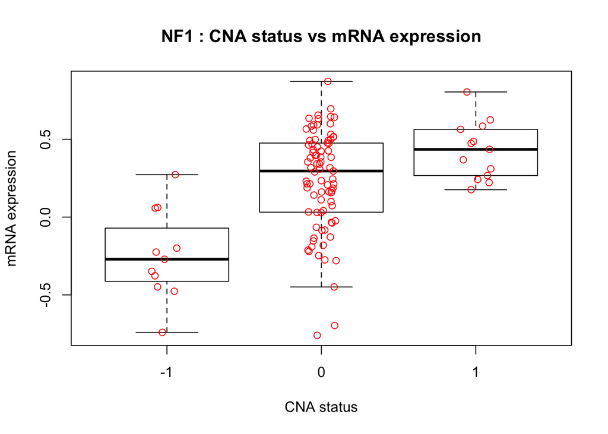

```r
boxplot(df[, 2] ~ df[, 1], main = "NF1 : CNA status vs mRNA expression", xlab = "CNA status",
    ylab = "mRNA expression", outpch = NA)
stripchart(df[, 2] ~ df[, 1], vertical = T, add = T, method = "jitter", pch = 1,
    col = "red")
```

Alternatively, the generic **cgdsr** **plot()** function can be used to generate a similar plot:

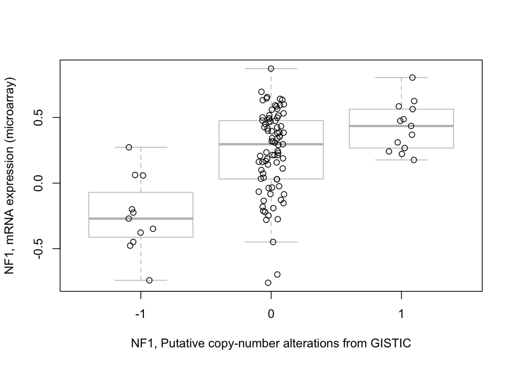

```
## [1] TRUE
```

```r
plot(mycgds, "gbm_tcga", "NF1", c("gbm_tcga_gistic", "gbm_tcga_mrna"), "gbm_tcga_3way_complete",
    skin = "disc_cont")
```

## Example 2: MDM2 and MDM4 mRNA expression levels in glioblastoma

In this example, we evaluate the relationship of MDM2 and MDM4 expression levels in glioblastoma. mRNA expression levels of MDM2 and MDM4 have been median adjusted on the gene level (by globally subtracting the median expression level of the individual gene across all samples).

```r
df <- getProfileData(mycgds, c("MDM2", "MDM4"), "gbm_tcga_mrna", "gbm_tcga_3way_complete")
head(df)
```

```
##                       MDM2       MDM4
## TCGA.02.0047.01        NaN        NaN
## TCGA.02.0055.01        NaN        NaN
## TCGA.06.0878.01  0.2522500 -0.1246364
## TCGA.06.0882.01 -0.1535625 -0.9700000
## TCGA.12.0821.01 -0.2926250  1.3305455
## TCGA.14.0787.01 -0.1856875  1.1394545
```

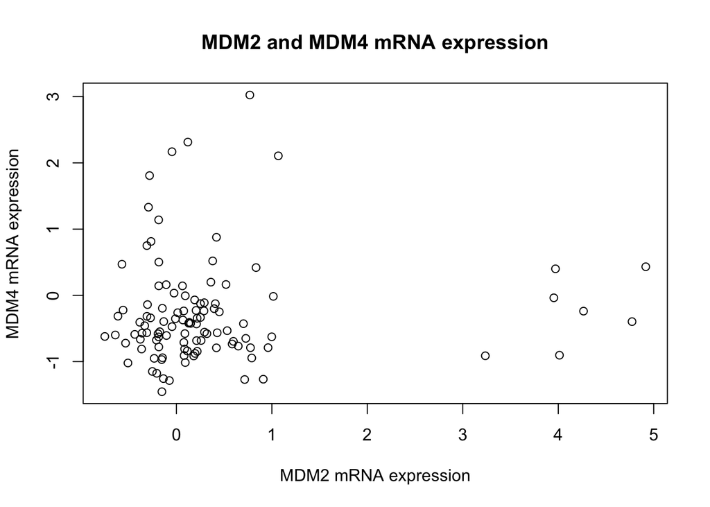

```r
plot(df, main = "MDM2 and MDM4 mRNA expression", xlab = "MDM2 mRNA expression",
    ylab = "MDM4 mRNA expression")
```

Alternatively, the generic **cgdsr** **plot()** function can be used to generate a similar plot:

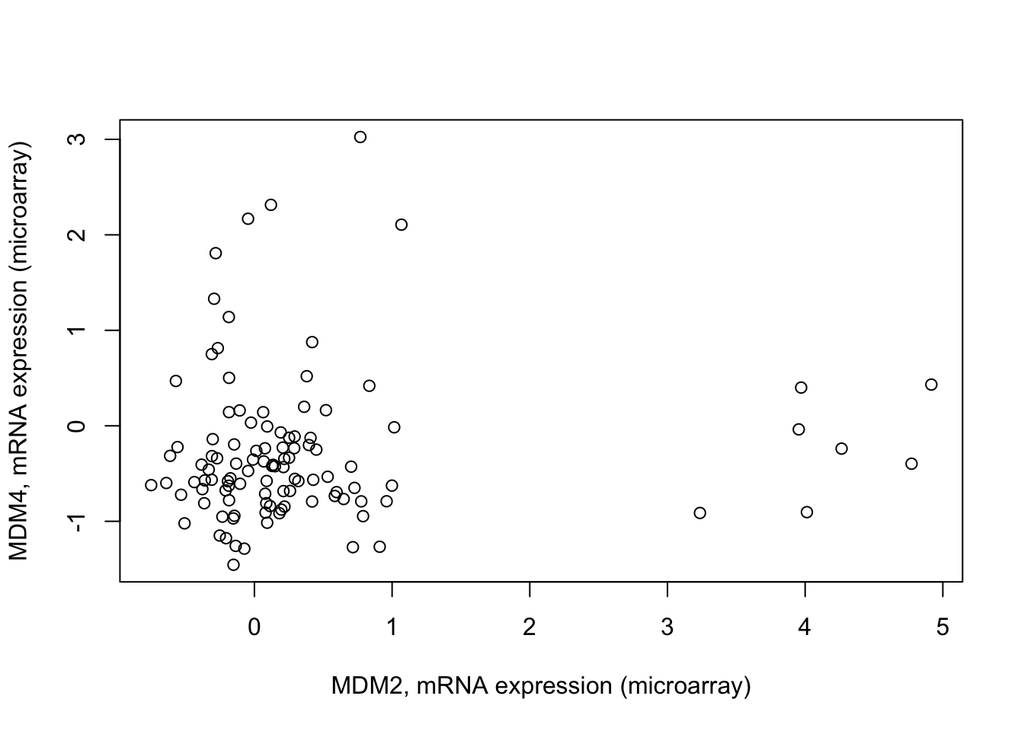

```
## [1] TRUE
```

```r
plot(mycgds, "gbm_tcga", c("MDM2", "MDM4"), "gbm_tcga_mrna", "gbm_tcga_3way_complete")
```

## Example 3: Comparing expression of PTEN in primary and metastatic prostate cancer tumors

In this example we plot the mRNA expression levels of PTEN in primary and metastatic prostate cancer tumors.

```r
df.pri <- getProfileData(mycgds, "PTEN", "prad_mskcc_mrna", "prad_mskcc_primary")
head(df.pri)
```

```
##             PTEN
## PCA0001 9.467183
## PCA0002 9.041528
## PCA0003 8.511305
## PCA0004      NaN
## PCA0005 9.413217
## PCA0006      NaN
```

```r
df.met <- getProfileData(mycgds, "PTEN", "prad_mskcc_mrna", "prad_mskcc_mets")
head(df.met)
```

```
##             PTEN
## PCA0182 7.486938
## PCA0183      NaN
## PCA0184 7.578755
## PCA0185      NaN
## PCA0186      NaN
## PCA0187 8.756132
```

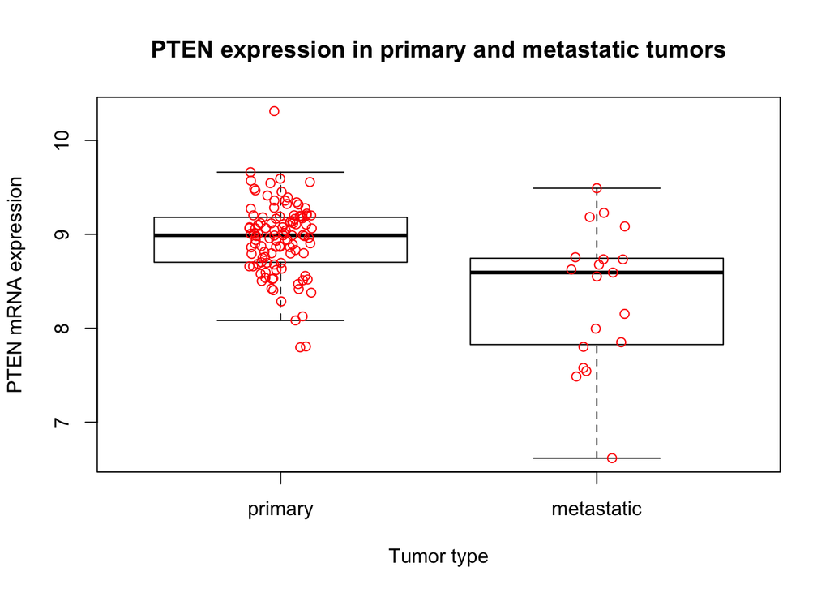

```r
boxplot(list(t(df.pri), t(df.met)), main = "PTEN expression in primary and metastatic tumors",
    xlab = "Tumor type", ylab = "PTEN mRNA expression", names = c("primary",
        "metastatic"), outpch = NA)
stripchart(list(t(df.pri), t(df.met)), vertical = T, add = T, method = "jitter",
    pch = 1, col = "red")
```